# IE 360 - Final

Irmak Dai

June 21, 2021

# 1 Introduction & Preparation

```r
library(tidyverse)
library(data.table)
library(forecast)
library(urca)
library(GGally)
library(zoo)
Sys.setlocale("LC_TIME", "English")
```

```r
rawdata <- read.csv("mcp_with_variables.csv")
```

## 1.1 Task 1

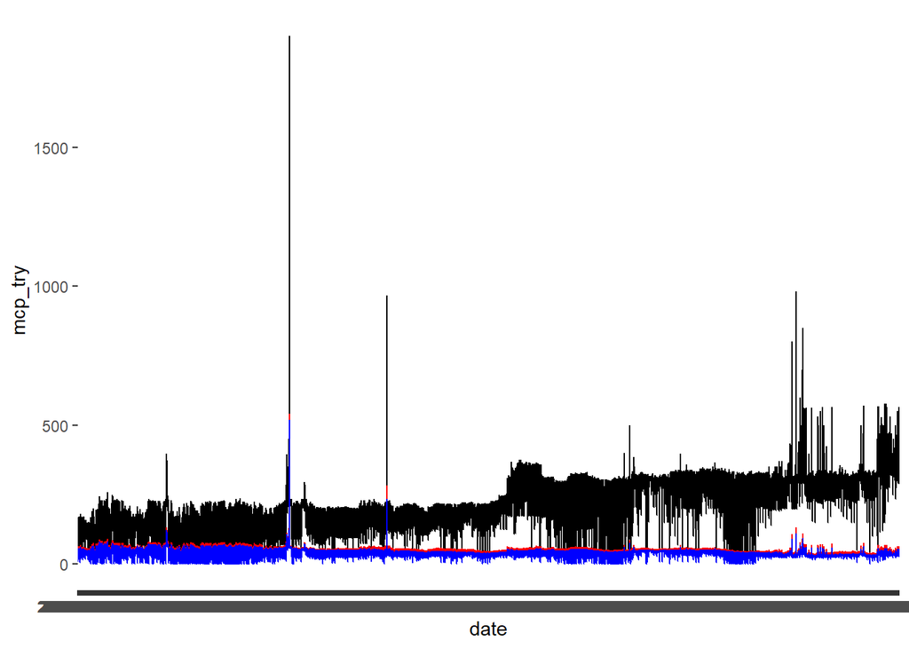

```r
ggplot(rawdata, aes(x=date))+
  geom_line(aes(y=mcp_try))+
  geom_line(aes(y=mcp_dollars), color="red")+
  geom_line(aes(y=mcp_euro), color="blue")
```

It is observed that the series in dollars and euro is more stabile than Turkish Lira. So, I decided to use the Dollar series.

## 1.2 Task 2

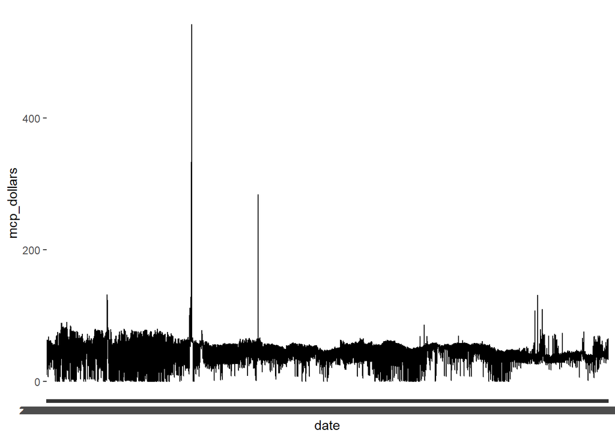

```r
ggplot(rawdata, aes(x=date))+
  geom_line(aes(y=mcp_dollars))
```

When we look at the overall image, the mean does not change much, but the variance changes over time, so it can be said that the series is not stationary. Also, there are some extreme outliers, which should be removed and replaced with mean values of previous and next few observations. Also it seems like we have seasonality.

## 1.3 Task 3

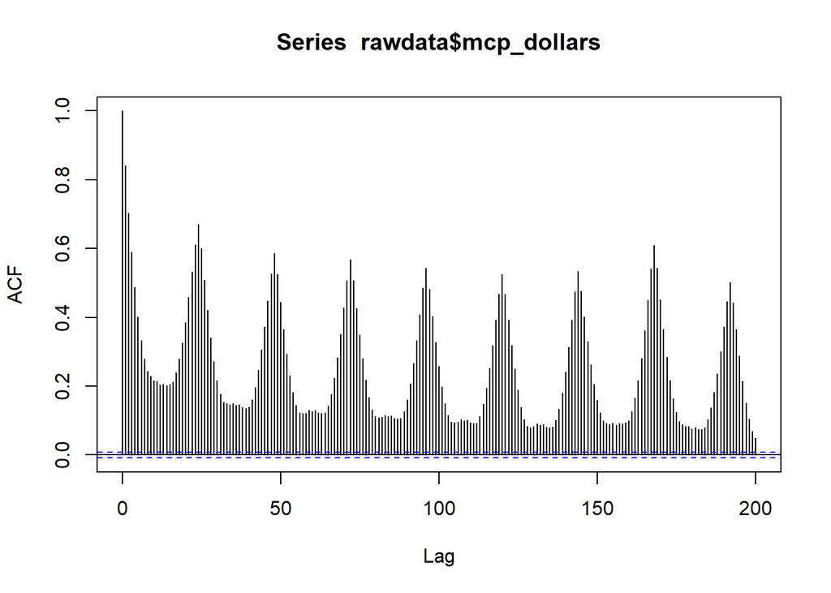

```r
acf(rawdata$mcp_dollars, lag.max = 200)
```

There is high autocorrelation in lag 24 and its multiples. Since we have hourly data, it indicates daily seasonality; the MCP values show similar pattern in the same hours of different days. Also, the autocorrelation in lag 168 `24*7` is slightly higher, which indicate weekly seasonality; MCP values show similar pattern in the same days of different weeks.

```r
str(rawdata)
```

```
## 'data.frame':    53112 obs. of  19 variables:
##  $ date       : chr  "2015-06-01" "2015-06-01" "2015-06-01" "2015-06-01" ...
##  $ hour       : int  0 1 2 3 4 5 6 7 8 9 ...
##  $ mcp_try    : num  103.8 88 49.1 33.8 28.9 ...
##  $ mcp_dollars: num  39 33.1 18.4 12.7 10.9 ...
##  $ mcp_euro   : num  35.61 30.19 16.83 11.59 9.93 ...
##  $ load_plan  : int  25600 23900 23000 22600 22500 21900 22300 25000 30200 33200 ...
##  $ total_prod : num  20657 20292 19666 19650 19664 ...
##  $ natural_gas: num  6198 6391 6403 6388 6300 ...
##  $ wind       : num  169 166 172 182 189 ...
##  $ lignite    : num  2799 2799 2799 2799 2799 ...
##  $ black_coal : num  742 630 630 630 630 630 630 742 742 714 ...
##  $ import_coal: num  3901 3708 3179 3112 3113 ...
##  $ fuel_oil   : num  417 417 417 417 417 417 417 417 462 462 ...
##  $ geothermal : num  74.8 74.8 74.8 74.8 74.8 74.8 74.8 74.8 74.8 74.8 ...
##  $ dam        : num  5057 4833 4726 4824 4798 ...
##  $ naphta     : num  0 0 0 0 0 0 0 0 0 0 ...
##  $ biomass    : num  0 0 0 0 0 0 0 0 0 0 ...
##  $ river      : num  1159 1134 1125 1082 1203 ...
##  $ other      : num  140 140 140 140 140 140 140 140 140 140 ...
```

```r
tidy_data <- rawdata %>%
  mutate(hour=ifelse(nchar(hour)==1, paste(0,hour,sep=""),hour)) %>%
  mutate(date_hour=paste(date,hour,sep = " ")) %>%
  mutate(date_hour=paste(date_hour,":00",sep = "")) %>%
  mutate(date_hour=as.POSIXct(date_hour, format="%Y-%m-%d %H:%M")) %>%
 # filter(date_hour<"2021-05-22") %>%
  mutate(date=as.Date(date, format="%Y-%m-%d")) %>%
  select(-c(mcp_try,mcp_euro))
```

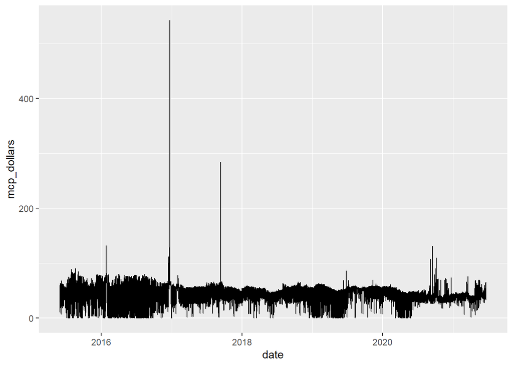

```r
ggplot(tidy_data, aes(x=date))+
  geom_line(aes(y=mcp_dollars))
```

Dealing with a few extreme outliers:

```r
while(TRUE){
  i <- which.max(tidy_data$mcp_dollars)
  if(tidy_data$mcp_dollars[i]>200){
    tidy_data$mcp_dollars[i] <- mean(c(tidy_data$mcp_dollars[i-48]:tidy_data$mcp_dollars[i+48]))
  }else{
    break
  }
}
```

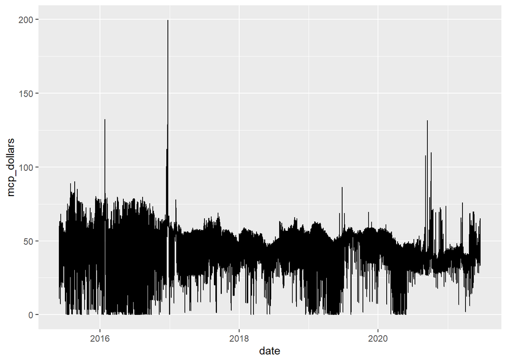

```r
ggplot(tidy_data, aes(x=date))+
  geom_line(aes(y=mcp_dollars))
```

Now we got rid off some extreme outliers. But also we have relatively higher values for these outliers, which help us not to lose information while getting rid of the outliers.

# 2 Analysis

## 2.1 Method A

### 2.1.1 Task 1

We have hourly data. That means we may have multiple types of seasonality: hourly, daily, weekly, monthly, etc.

#### 2.1.1.1 Hourly decomposition

There is not any clear increase in the variance, so I used additive model.

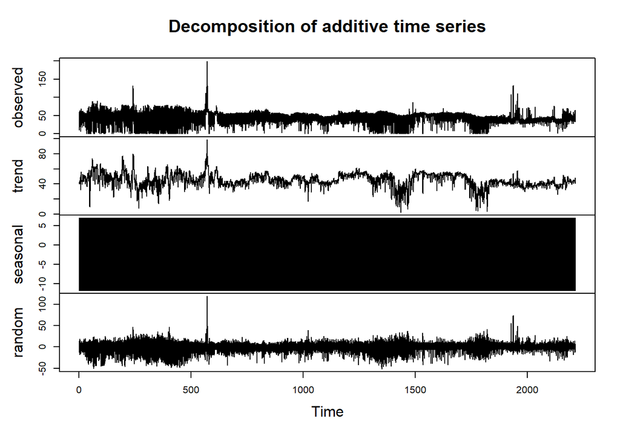

```r
ts_hourly <- ts(tidy_data$mcp_dollars, frequency = 24)
decomposed_hourly <- decompose(ts_hourly, type="additive")
plot(decomposed_hourly)
```

Random component looks like it has zero mean. Variance changes sometimes, but in overall it may be satisfactory. It looks like there is some seasonality in the trend, which is unfavorable.

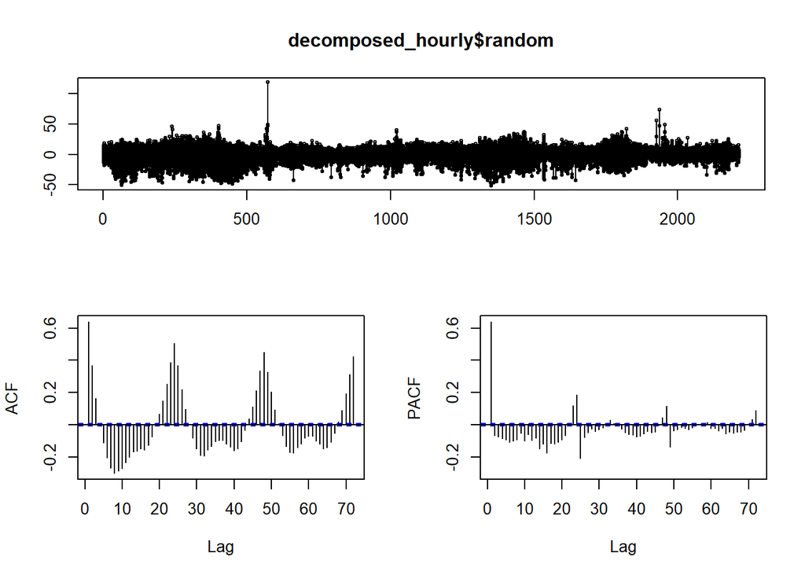

```r
tsdisplay(decomposed_hourly$random)
```

Random component is autocorrelated.

```r
decomposed_hourly$random %>%
  ur.kpss() %>%
  summary()
```

```
##
## #######################
## # KPSS Unit Root Test #
## #######################
##
## Test is of type: mu with 19 lags.
##
## Value of test-statistic is: 3e-04
##
## Critical value for a significance level of:
##                 10pct  5pct 2.5pct  1pct
## critical values 0.347 0.463  0.574 0.739
```

The test statistic is very small, which support stationarity assumption.

#### 2.1.1.2 Daily decomposition

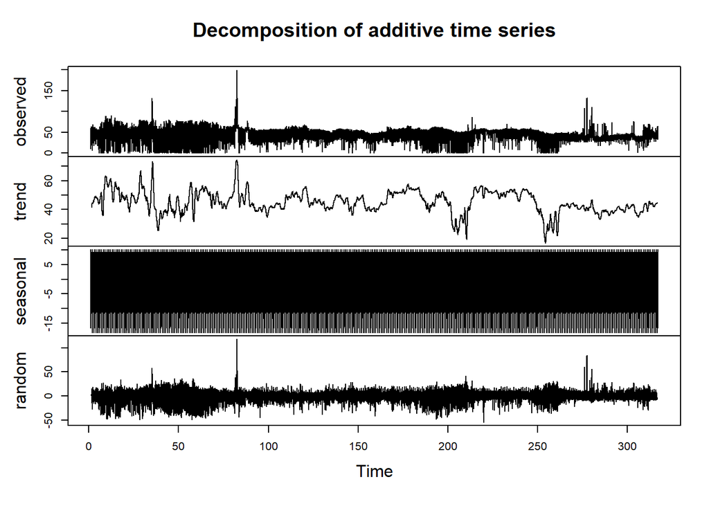

```r
ts_daily <- ts(tidy_data$mcp_dollars, frequency = 24*7)
decomposed_daily <- decompose(ts_daily, type="additive")
plot(decomposed_daily)
```

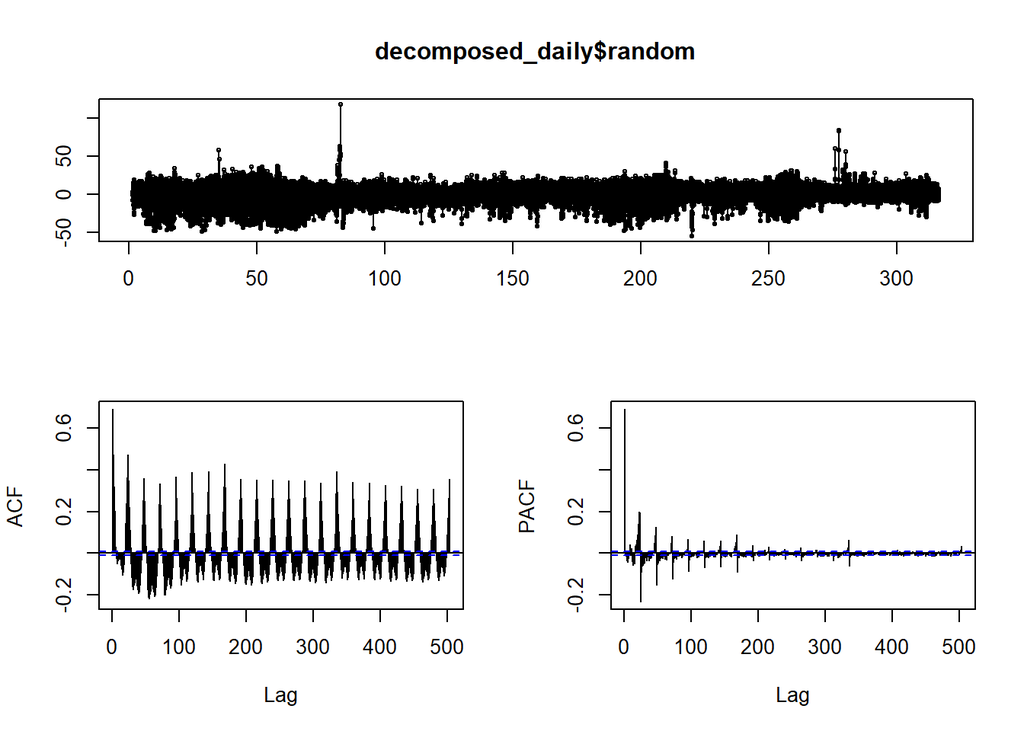

```r
tsdisplay(decomposed_daily$random)
```

```r
decomposed_daily$random %>%
  ur.kpss() %>%
  summary()
```

```
##
## #######################
## # KPSS Unit Root Test #
## #######################
##
## Test is of type: mu with 19 lags.
##
## Value of test-statistic is: 8e-04
##
## Critical value for a significance level of:
##                 10pct  5pct 2.5pct  1pct
## critical values 0.347 0.463  0.574 0.739
```

Test statistic is very low, which supports the stationarity of data. We can continue with this series to build arima model.

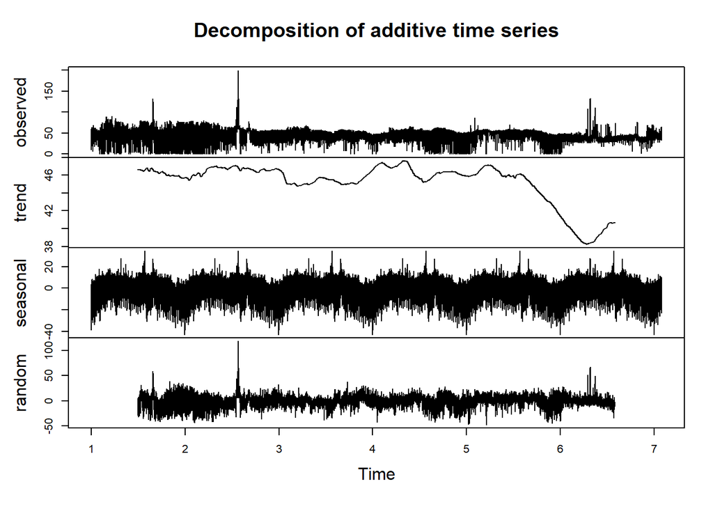

```r
ts_monthly <- ts(tidy_data$mcp_dollars, frequency = 24*7*52)
decomposed_monthly <- decompose(ts_monthly, type="additive")
plot(decomposed_monthly)
```

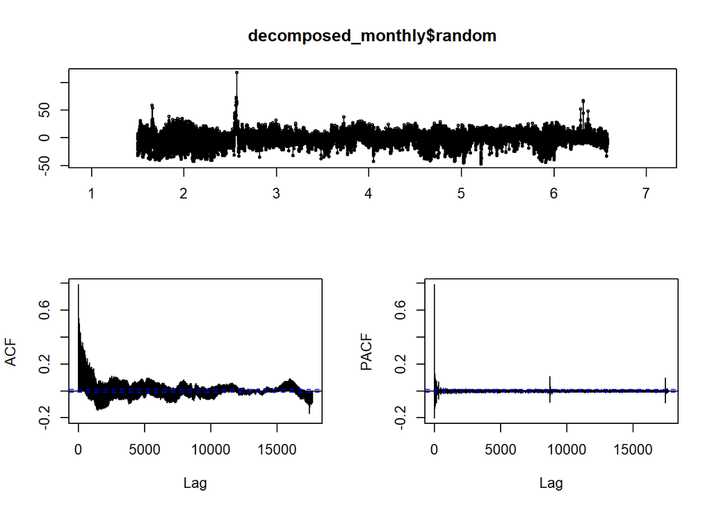

```r
tsdisplay(decomposed_monthly$random)
```

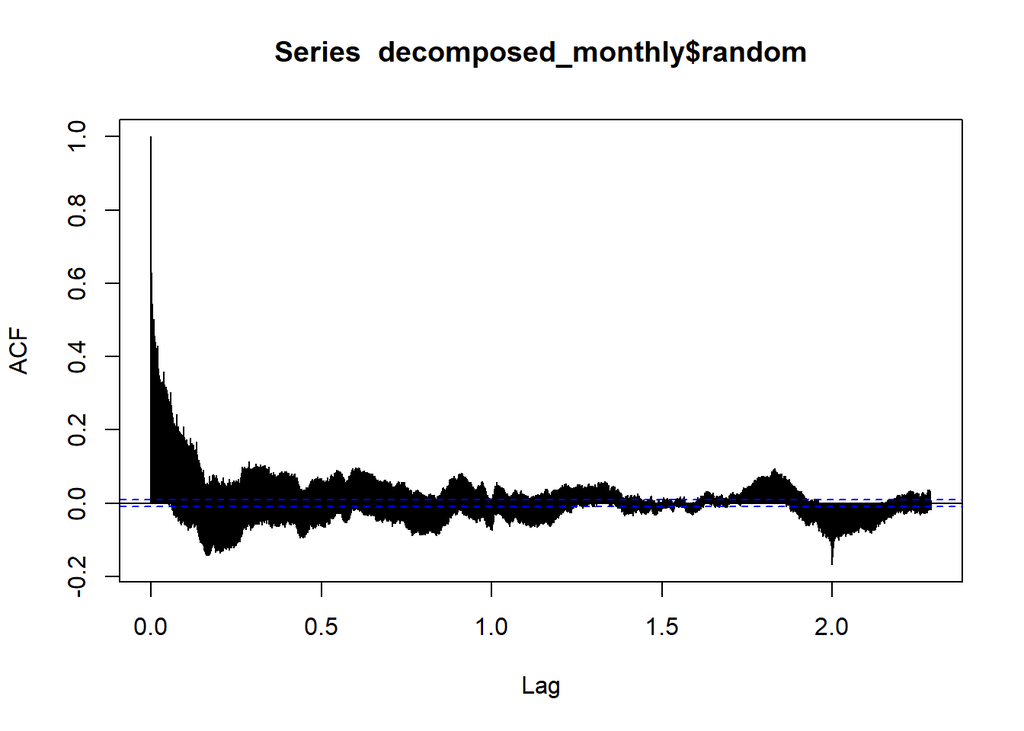

```r
acf(decomposed_monthly$random, na.action = na.pass, lag.max = 20000)
```

```r
decomposed_monthly$random %>%
  ur.kpss() %>%
  summary()
```

```
##
## #######################
## # KPSS Unit Root Test #
## #######################
##
## Test is of type: mu with 18 lags.
##
## Value of test-statistic is: 0.9106
##
## Critical value for a significance level of:
##                 10pct  5pct 2.5pct  1pct
## critical values 0.347 0.463  0.574 0.739
```

Random component is not stationary, let’s not use this model.

### 2.1.2 Task 2

I decided to go forward with daily decomposition, because from my analysis I believe that there is both daily and weekly seasonality.

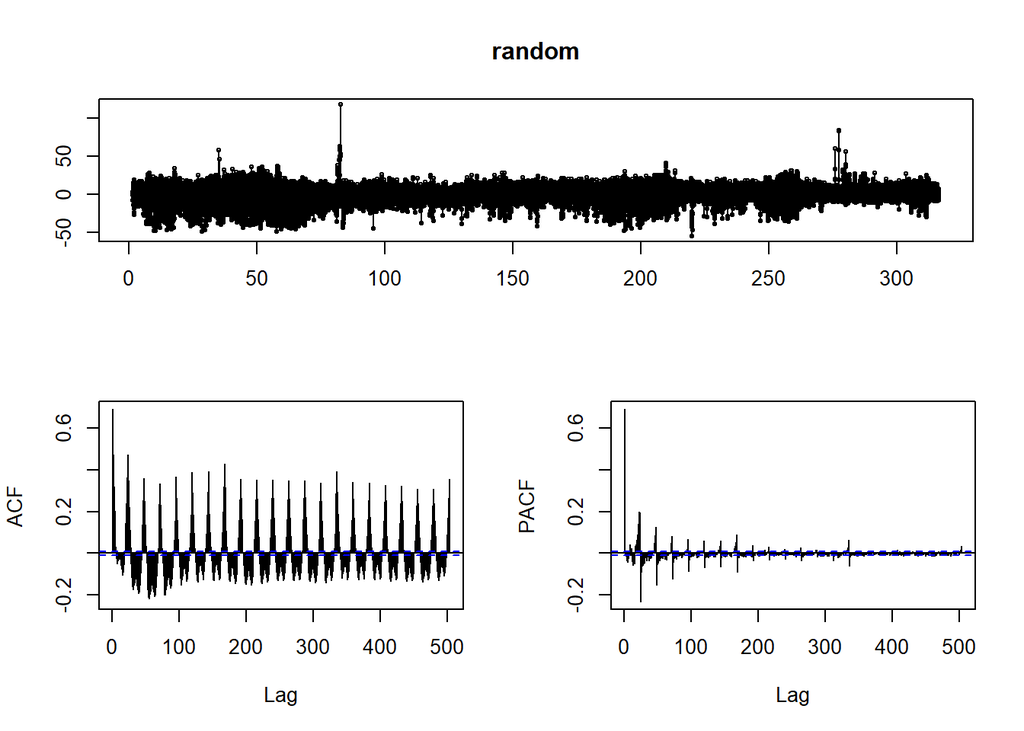

```r
random <- decomposed_daily$random
tsdisplay(random)
```

We have sinusoidal ACF. AR models would be probably suitable.

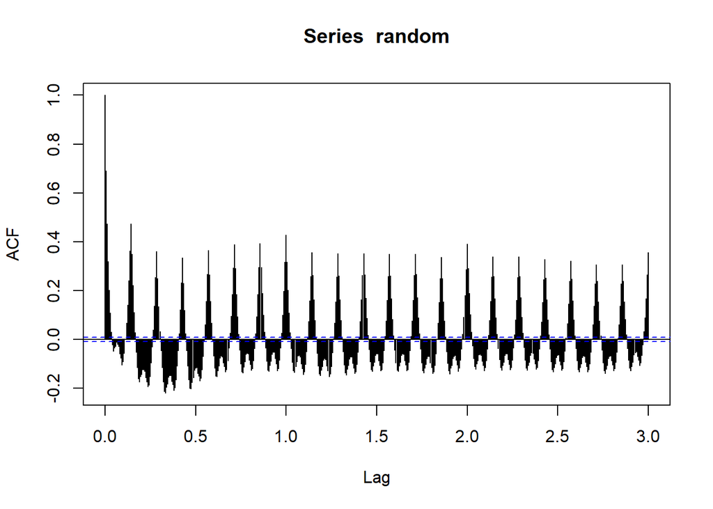

```r
acf(random,na.action = na.pass, lag.max = 24*7*3)
```

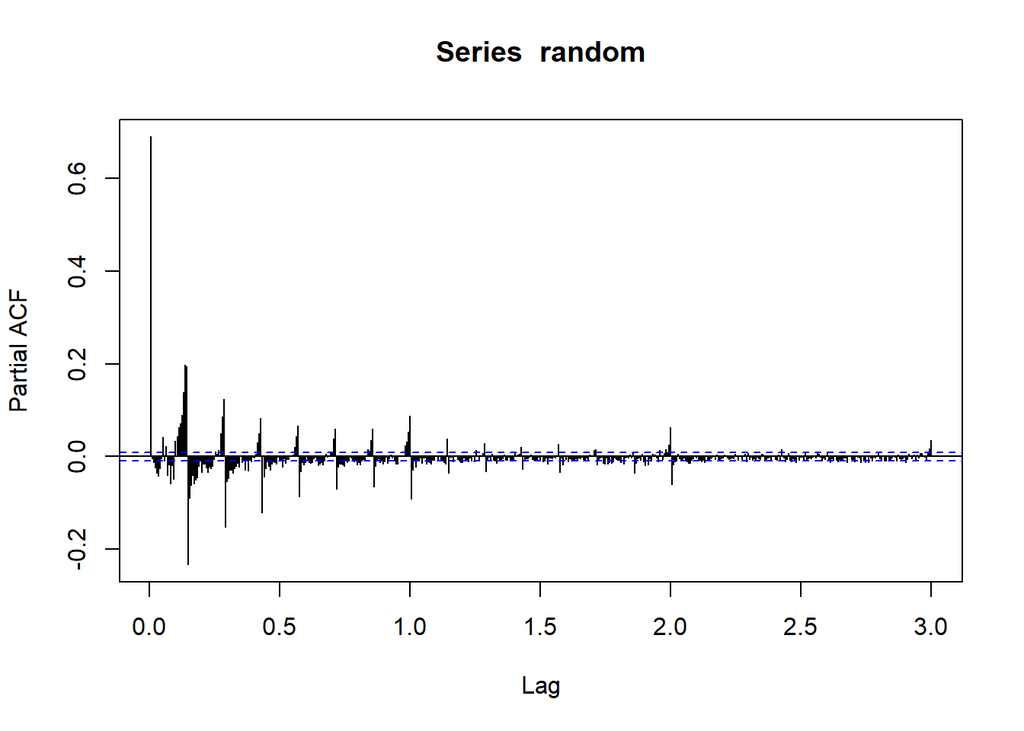

```r
pacf(random, na.action = na.pass, lag.max = 24*7*3)
```

```r
# aa_fit <- auto.arima(random)
# summary(aa_fit)
```

Auto arima suggested AR model of order 1. Let’s try a few models more: (I commented auto.arima to reduce execution time)

```r
fit <- arima(random, order=c(1,0,0))
summary(fit)
```

```
##
## Call:
## arima(x = random, order = c(1, 0, 0))
##
## Coefficients:
##          ar1  intercept
##       0.6898     0.0001
## s.e.  0.0031     0.0908
##
## sigma^2 estimated as 41.99:  log likelihood = -174063.1,  aic = 348132.1
##
## Training set error measures:
##                         ME     RMSE    MAE      MPE     MAPE      MASE
## Training set -7.040132e-05 6.480113 4.2697 44.71341 293.3772 0.9775777
##                     ACF1
## Training set 0.002669765
```

```r
fit1 <- arima(random, order=c(1,0,1))
summary(fit1)
```

```
##
## Call:
## arima(x = random, order = c(1, 0, 1))
##
## Coefficients:
##          ar1     ma1  intercept
##       0.6869  0.0054     0.0001
## s.e.  0.0045  0.0062     0.0904
##
## sigma^2 estimated as 41.99:  log likelihood = -174062.7,  aic = 348133.4
##
## Training set error measures:
##                         ME     RMSE      MAE      MPE     MAPE      MASE
## Training set -6.991786e-05 6.480066 4.269403 44.61675 293.3946 0.9775098
##                     ACF1
## Training set 5.60544e-05
```

```r
fit2 <- arima(random, order = c(2,0,0))
summary(fit2)
```

```
##
## Call:
## arima(x = random, order = c(2, 0, 0))
##
## Coefficients:
##          ar1      ar2  intercept
##       0.6924  -0.0039     0.0001
## s.e.  0.0043   0.0043     0.0904
##
## sigma^2 estimated as 41.99:  log likelihood = -174062.7,  aic = 348133.3
##
## Training set error measures:
##                         ME     RMSE      MAE      MPE     MAPE      MASE
## Training set -6.990345e-05 6.480065 4.269367 44.61258 293.4035 0.9775015
##                       ACF1
## Training set -6.132169e-05
```

I observed that seasonal orders have too high execution times for this dataset. So I decided not to use them.

It seems like AR model of order 1 works fine. It is also the one with the lowest AIC.

### 2.1.3 Task 4 (3 was missing in the description)

```r
test_dates <- c(as.Date("2021-05-22"):as.Date("2021-06-21"))
```

```r
tidy_data <- as.data.frame(tidy_data)
```

```r
df <- data.frame(matrix(nrow = 24, ncol = length(test_dates)))
rownames(df) <- c(0:23)
colnames(df) <- as.Date.numeric(test_dates)
```

```r
for(i in 1:length(test_dates)){

    current_date=test_dates[i]-2

    past_data <- tidy_data %>%
      filter(date<=current_date)

    ts <- ts(past_data$mcp_dollars, frequency = 24*7)
    decomposed <- decompose(ts, type="additive")
    model <- arima(decomposed$random,order = c(1,0,0))
    forecasted=predict(model,n.ahead = 48)
    latest_trend <- decomposed$trend[max(which(!is.na(decomposed$trend)))]
    trend_vec <- rep(latest_trend,24)
    next_day <- tail(forecasted$pred, 24)
    n <- nrow(past_data)
    seasonality <- decomposed$seasonal[(n+25-168):(n+48-168)]
    df[,i] <- c(trend_vec+next_day+seasonality)

}
```

```r
df
```

```
##    2021-05-22 2021-05-23 2021-05-24 2021-05-25 2021-05-26 2021-05-27 2021-05-28
## 0    46.58761   46.49084   42.44921   45.87990   45.56439   44.11048   43.88173
## 1    44.91734   44.64795   40.37322   44.29954   43.41573   42.97285   42.30259
## 2    40.50704   39.07978   35.57610   40.35001   39.68120   39.21613   38.42467
## 3    36.64440   34.81178   31.34960   36.26842   35.40816   34.83280   34.23804
## 4    35.33979   33.55807   29.41097   34.16193   34.01330   32.96506   32.84099
## 5    34.22541   31.81107   29.01242   34.84958   34.12493   33.67621   33.28036
## 6    32.89612   28.84565   32.22276   35.96054   35.66353   34.79308   34.60716
## 7    36.92369   26.85107   42.29410   42.85125   43.00055   42.10384   41.74322
## 8    44.33625   27.55883   50.85856   50.34311   50.09354   49.00444   49.05118
## 9    48.32125   30.79953   54.00265   53.00447   52.76801   52.06345   52.31137
## 10   50.12133   35.93680   54.47288   53.98917   53.67647   52.56255   52.21261
## 11   52.01546   39.92885   55.92735   54.66261   54.39297   53.66806   53.16053
## 12   47.02145   37.32988   49.89616   48.49837   48.91353   47.76259   46.52334
## 13   48.50326   39.78220   51.73449   50.65381   50.91632   49.90539   44.37209
```

[output cut: 110 more lines]

## 2.2 Method B

### 2.2.1 Task 1

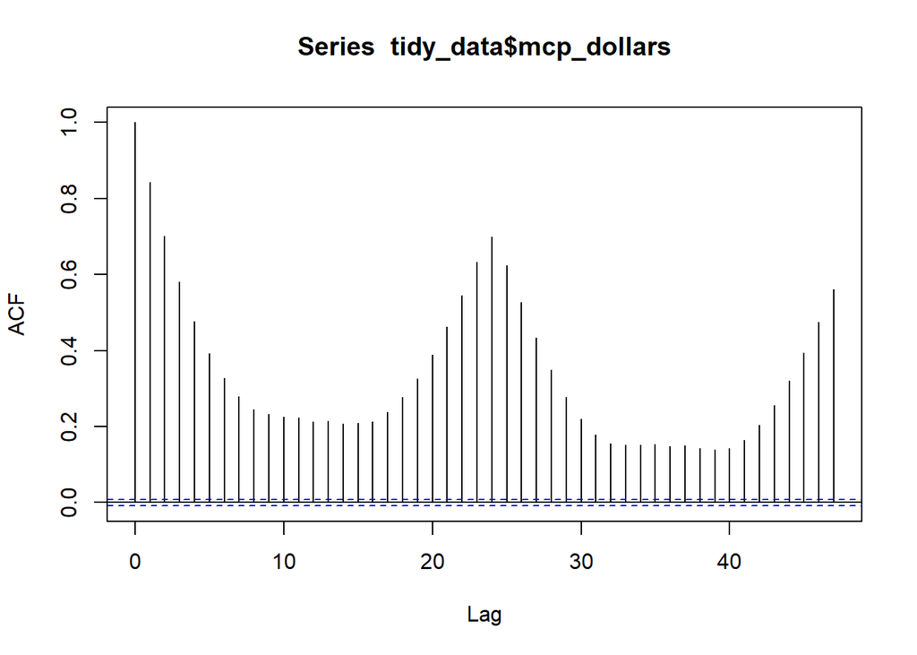

```r
acf(tidy_data$mcp_dollars)
```

Autocorrelation is high in lag 1. Since we are forecasting 2 days ahead, let’s use lag 2 value as a regressor for convenience.

```r
tidy_data <- as.data.table(tidy_data)
tidy_data[,lagged2_mcp:=lag(mcp_dollars,2)]
```

```r
tidy_data[,hour:=as.numeric(hour)]
```

In our previous analysis, we decided that there is weekly and daily seasonality.

```r
tidy_data[,day:=weekdays(date_hour)]
tidy_data[,month:=month(date_hour)]
```

```r
tidy_data[,ratio_renewable:=(wind+river+geothermal+dam)/total_prod]
tidy_data[,trend:=c(1:.N)]
```

```r
full_data <- tidy_data
```

```r
tidy_data <- tidy_data[date<"2021-05-22",]
```

### 2.2.2 Task 2-3

Let’s start with a simple model:

```r
lm1 <- lm(mcp_dollars~as.factor(hour)+as.factor(day)+as.factor(month)+lagged2_mcp, data=tidy_data)
summary(lm1)
```

```
##
## Call:
## lm(formula = mcp_dollars ~ as.factor(hour) + as.factor(day) +
##     as.factor(month) + lagged2_mcp, data = tidy_data)
##
## Residuals:
##     Min      1Q  Median      3Q     Max
## -86.522  -3.842   0.374   4.337 131.845
##
## Coefficients:
##                         Estimate Std. Error t value Pr(>|t|)
## (Intercept)             15.78303    0.29240  53.977  < 2e-16 ***
## as.factor(hour)1         0.96426    0.26313   3.665 0.000248 ***
## as.factor(hour)2        -5.14205    0.26279 -19.567  < 2e-16 ***
## as.factor(hour)3        -8.18307    0.26298 -31.116  < 2e-16 ***
## as.factor(hour)4        -6.97242    0.26389 -26.422  < 2e-16 ***
## as.factor(hour)5        -4.41218    0.26552 -16.617  < 2e-16 ***
## as.factor(hour)6        -2.77392    0.26634 -10.415  < 2e-16 ***
## as.factor(hour)7         3.18627    0.26644  11.959  < 2e-16 ***
## as.factor(hour)8         9.31416    0.26613  34.999  < 2e-16 ***
## as.factor(hour)9         8.63086    0.26376  32.723  < 2e-16 ***
## as.factor(hour)10        5.74241    0.26276  21.854  < 2e-16 ***
## as.factor(hour)11        5.21410    0.26290  19.833  < 2e-16 ***
## as.factor(hour)12       -1.10016    0.26310  -4.182 2.90e-05 ***
## as.factor(hour)13       -0.69189    0.26341  -2.627 0.008624 **
## as.factor(hour)14        5.07997    0.26275  19.334  < 2e-16 ***
## as.factor(hour)15        3.11836    0.26281  11.866  < 2e-16 ***
## as.factor(hour)16        1.97218    0.26306   7.497 6.63e-14 ***
## as.factor(hour)17        2.04432    0.26292   7.776 7.65e-15 ***
## as.factor(hour)18        1.77902    0.26296   6.765 1.34e-11 ***
## as.factor(hour)19        3.21500    0.26288  12.230  < 2e-16 ***
## as.factor(hour)20        3.63380    0.26288  13.823  < 2e-16 ***
## as.factor(hour)21        1.53818    0.26301   5.848 4.99e-09 ***
## as.factor(hour)22       -1.18236    0.26306  -4.495 6.99e-06 ***
## as.factor(hour)23       -4.34885    0.26288 -16.543  < 2e-16 ***
## as.factor(day)Monday    -0.24870    0.14187  -1.753 0.079611 .
## as.factor(day)Saturday  -0.61073    0.14203  -4.300 1.71e-05 ***
## as.factor(day)Sunday    -2.54263    0.14404 -17.652  < 2e-16 ***
## as.factor(day)Thursday   0.11557    0.14183   0.815 0.415160
## as.factor(day)Tuesday    0.04926    0.14183   0.347 0.728329
## as.factor(day)Wednesday  0.04475    0.14182   0.316 0.752338
## as.factor(month)2       -0.86599    0.18812  -4.604 4.16e-06 ***
## as.factor(month)3       -2.14797    0.18480 -11.623  < 2e-16 ***
## as.factor(month)4       -3.17156    0.18766 -16.901  < 2e-16 ***
## as.factor(month)5       -3.19025    0.18873 -16.904  < 2e-16 ***
## as.factor(month)6       -1.38855    0.18571  -7.477 7.72e-14 ***
## as.factor(month)7        0.16001    0.18369   0.871 0.383726
## as.factor(month)8        1.26537    0.18412   6.873 6.37e-12 ***
## as.factor(month)9        0.84727    0.18540   4.570 4.89e-06 ***
## as.factor(month)10       0.02400    0.18369   0.131 0.896037
## as.factor(month)11      -0.13664    0.18521  -0.738 0.460661
## as.factor(month)12       0.58264    0.18378   3.170 0.001524 **
## lagged2_mcp              0.65611    0.00330 198.833  < 2e-16 ***
## ---
## Signif. codes:  0 '***' 0.001 '**' 0.01 '*' 0.05 '.' 0.1 ' ' 1
##
## Residual standard error: 8.678 on 52323 degrees of freedom
##   (3 observations deleted due to missingness)
## Multiple R-squared:  0.6088, Adjusted R-squared:  0.6085
## F-statistic:  1986 on 41 and 52323 DF,  p-value: < 2.2e-16
```

```r
lm2 <- lm(mcp_dollars~as.factor(hour)+as.factor(day)+as.factor(month)+lagged2_mcp+ratio_renewable, data=tidy_data)
summary(lm2)
```

```
##
## Call:
## lm(formula = mcp_dollars ~ as.factor(hour) + as.factor(day) +
##     as.factor(month) + lagged2_mcp + ratio_renewable, data = tidy_data)
##
## Residuals:
##     Min      1Q  Median      3Q     Max
## -82.728  -3.907   0.288   4.381 134.184
##
## Coefficients:
##                           Estimate Std. Error t value Pr(>|t|)
## (Intercept)              19.640192   0.330561  59.415  < 2e-16 ***
## as.factor(hour)1          0.651598   0.261944   2.488 0.012866 *
## as.factor(hour)2         -5.538418   0.261796 -21.155  < 2e-16 ***
## as.factor(hour)3         -8.643067   0.262158 -32.969  < 2e-16 ***
## as.factor(hour)4         -7.498212   0.263261 -28.482  < 2e-16 ***
## as.factor(hour)5         -5.015422   0.265158 -18.915  < 2e-16 ***
## as.factor(hour)6         -3.422009   0.266139 -12.858  < 2e-16 ***
## as.factor(hour)7          2.524389   0.266296   9.480  < 2e-16 ***
## as.factor(hour)8          8.965144   0.264995  33.831  < 2e-16 ***
## as.factor(hour)9          8.658611   0.262258  33.016  < 2e-16 ***
## as.factor(hour)10         5.958681   0.261411  22.794  < 2e-16 ***
## as.factor(hour)11         5.552901   0.261773  21.213  < 2e-16 ***
## as.factor(hour)12        -0.888164   0.261744  -3.393 0.000691 ***
## as.factor(hour)13        -0.421261   0.262139  -1.607 0.108058
## as.factor(hour)14         5.355068   0.261500  20.478  < 2e-16 ***
## as.factor(hour)15         3.409399   0.261582  13.034  < 2e-16 ***
## as.factor(hour)16         2.317491   0.261942   8.847  < 2e-16 ***
## as.factor(hour)17         2.421119   0.261873   9.245  < 2e-16 ***
## as.factor(hour)18         2.166976   0.261938   8.273  < 2e-16 ***
## as.factor(hour)19         3.587190   0.261830  13.700  < 2e-16 ***
## as.factor(hour)20         3.988371   0.261783  15.235  < 2e-16 ***
## as.factor(hour)21         1.823574   0.261770   6.966 3.29e-12 ***
## as.factor(hour)22        -0.874073   0.261871  -3.338 0.000845 ***
## as.factor(hour)23        -4.204848   0.261450 -16.083  < 2e-16 ***
## as.factor(day)Monday     -0.204293   0.141076  -1.448 0.147593
## as.factor(day)Saturday   -0.612062   0.141219  -4.334 1.47e-05 ***
## as.factor(day)Sunday     -2.571404   0.143227 -17.953  < 2e-16 ***
## as.factor(day)Thursday    0.138128   0.141025   0.979 0.327358
## as.factor(day)Tuesday     0.066016   0.141023   0.468 0.639700
## as.factor(day)Wednesday   0.050200   0.141018   0.356 0.721856
## as.factor(month)2        -0.769735   0.187087  -4.114 3.89e-05 ***
## as.factor(month)3        -1.274567   0.187167  -6.810 9.88e-12 ***
## as.factor(month)4        -1.672685   0.196347  -8.519  < 2e-16 ***
## as.factor(month)5        -1.608415   0.198431  -8.106 5.36e-16 ***
## as.factor(month)6        -0.667631   0.186976  -3.571 0.000356 ***
## as.factor(month)7         0.356987   0.182823   1.953 0.050868 .
## as.factor(month)8         1.403451   0.183157   7.663 1.85e-14 ***
## as.factor(month)9         0.566715   0.184701   3.068 0.002154 **
## as.factor(month)10       -0.684027   0.184909  -3.699 0.000216 ***
## as.factor(month)11       -0.863051   0.186523  -4.627 3.72e-06 ***
## as.factor(month)12        0.356495   0.182972   1.948 0.051377 .
## lagged2_mcp               0.641030   0.003338 192.027  < 2e-16 ***
## ratio_renewable         -10.128419   0.413045 -24.521  < 2e-16 ***
## ---
## Signif. codes:  0 '***' 0.001 '**' 0.01 '*' 0.05 '.' 0.1 ' ' 1
##
## Residual standard error: 8.628 on 52322 degrees of freedom
##   (3 observations deleted due to missingness)
## Multiple R-squared:  0.6132, Adjusted R-squared:  0.6129
## F-statistic:  1975 on 42 and 52322 DF,  p-value: < 2.2e-16
```

Ratio of the renewable energy production is also significant.

```r
lm3 <- lm(mcp_dollars~as.factor(hour)+as.factor(day)+lagged2_mcp+ratio_renewable+as.factor(month)+trend, data=tidy_data)
summary(lm3)
```

```
##
## Call:
## lm(formula = mcp_dollars ~ as.factor(hour) + as.factor(day) +
##     lagged2_mcp + ratio_renewable + as.factor(month) + trend,
##     data = tidy_data)
##
## Residuals:
##     Min      1Q  Median      3Q     Max
## -82.898  -3.849   0.324   4.392 133.752
##
## Coefficients:
##                           Estimate Std. Error t value Pr(>|t|)
## (Intercept)              1.986e+01  3.322e-01  59.780  < 2e-16 ***
## as.factor(hour)1         6.735e-01  2.619e-01   2.572 0.010113 *
## as.factor(hour)2        -5.498e+00  2.618e-01 -21.001  < 2e-16 ***
## as.factor(hour)3        -8.601e+00  2.621e-01 -32.809  < 2e-16 ***
## as.factor(hour)4        -7.463e+00  2.632e-01 -28.354  < 2e-16 ***
## as.factor(hour)5        -4.986e+00  2.651e-01 -18.808  < 2e-16 ***
## as.factor(hour)6        -3.393e+00  2.661e-01 -12.751  < 2e-16 ***
## as.factor(hour)7         2.554e+00  2.662e-01   9.595  < 2e-16 ***
## as.factor(hour)8         8.961e+00  2.649e-01  33.829  < 2e-16 ***
## as.factor(hour)9         8.631e+00  2.622e-01  32.920  < 2e-16 ***
## as.factor(hour)10        5.932e+00  2.613e-01  22.699  < 2e-16 ***
## as.factor(hour)11        5.523e+00  2.617e-01  21.104  < 2e-16 ***
## as.factor(hour)12       -8.985e-01  2.616e-01  -3.434 0.000595 ***
## as.factor(hour)13       -4.331e-01  2.620e-01  -1.653 0.098418 .
## as.factor(hour)14        5.324e+00  2.614e-01  20.364  < 2e-16 ***
## as.factor(hour)15        3.382e+00  2.615e-01  12.930  < 2e-16 ***
## as.factor(hour)16        2.291e+00  2.619e-01   8.749  < 2e-16 ***
## as.factor(hour)17        2.388e+00  2.618e-01   9.119  < 2e-16 ***
## as.factor(hour)18        2.133e+00  2.619e-01   8.145 3.86e-16 ***
## as.factor(hour)19        3.553e+00  2.618e-01  13.573  < 2e-16 ***
## as.factor(hour)20        3.956e+00  2.617e-01  15.115  < 2e-16 ***
## as.factor(hour)21        1.803e+00  2.617e-01   6.890 5.65e-12 ***
## as.factor(hour)22       -8.960e-01  2.618e-01  -3.423 0.000621 ***
## as.factor(hour)23       -4.213e+00  2.614e-01 -16.119  < 2e-16 ***
## as.factor(day)Monday    -2.142e-01  1.410e-01  -1.519 0.128871
## as.factor(day)Saturday  -6.179e-01  1.412e-01  -4.377 1.21e-05 ***
## as.factor(day)Sunday    -2.594e+00  1.432e-01 -18.115  < 2e-16 ***
## as.factor(day)Thursday   1.361e-01  1.410e-01   0.965 0.334429
```

[output cut: 8 more lines]

```
## as.factor(month)6       -8.562e-01  1.892e-01  -4.525 6.05e-06 ***
## as.factor(month)7        2.574e-01  1.834e-01   1.403 0.160476
## as.factor(month)8        1.335e+00  1.834e-01   7.280 3.38e-13 ***
## as.factor(month)9        5.554e-01  1.846e-01   3.008 0.002630 **
## as.factor(month)10      -6.413e-01  1.850e-01  -3.467 0.000526 ***
## as.factor(month)11      -8.067e-01  1.867e-01  -4.322 1.55e-05 ***
## as.factor(month)12       3.756e-01  1.829e-01   2.053 0.040045 *
## trend                   -1.785e-05  2.791e-06  -6.396 1.61e-10 ***
## ---
## Signif. codes:  0 '***' 0.001 '**' 0.01 '*' 0.05 '.' 0.1 ' ' 1
##
## Residual standard error: 8.625 on 52321 degrees of freedom
##   (3 observations deleted due to missingness)
## Multiple R-squared:  0.6135, Adjusted R-squared:  0.6132
## F-statistic:  1932 on 43 and 52321 DF,  p-value: < 2.2e-16
```

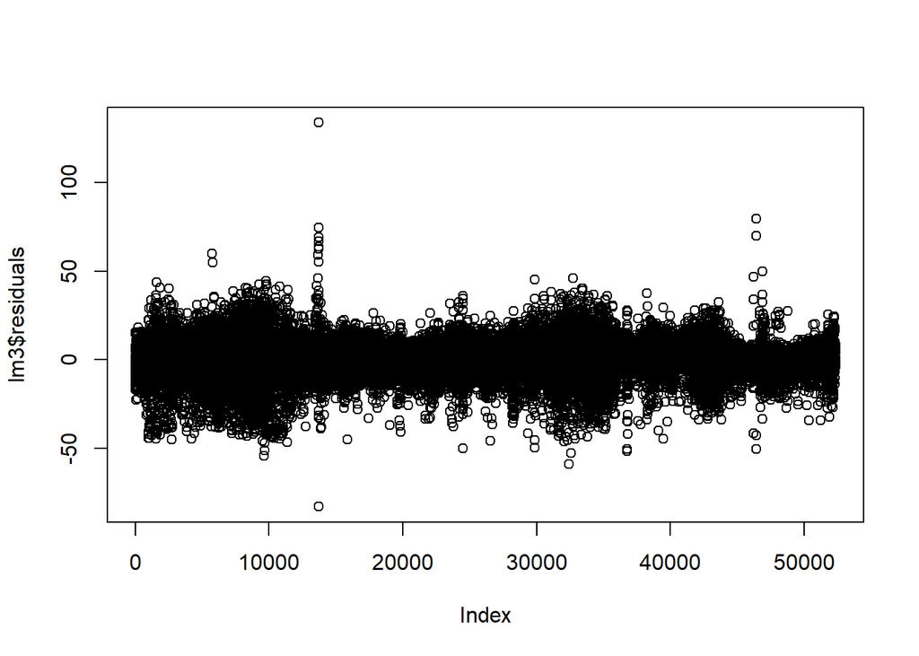

```r
plot(lm3$residuals)
```

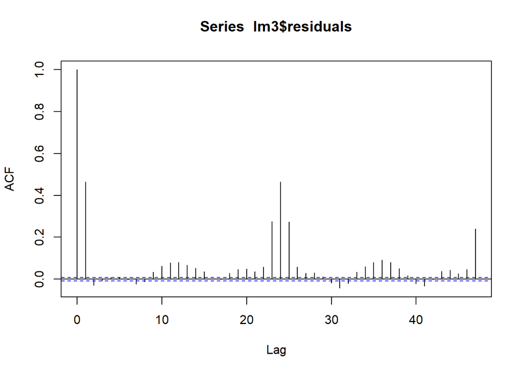

```r
acf(lm3$residuals)
```

Unfortunately, residuals are autocorrelated.

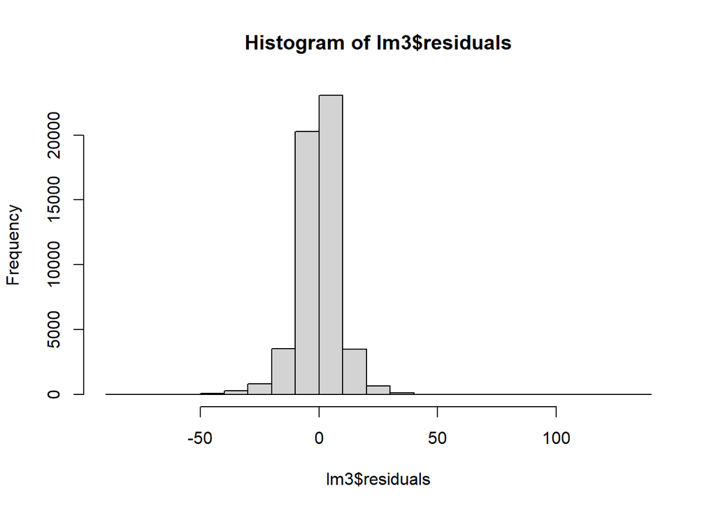

```r
hist(lm3$residuals)
```

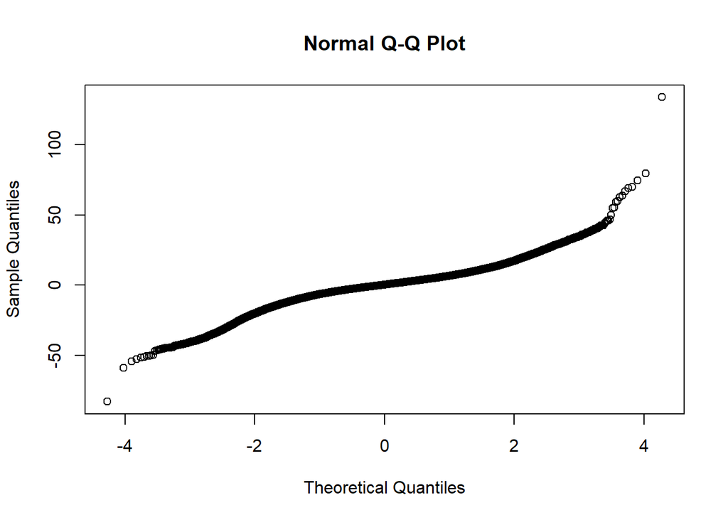

```r
qqnorm(lm3$residuals)
```

### 2.2.3 Task 4

```r
df2 <- data.frame(matrix(nrow = 24, ncol = length(test_dates)))
rownames(df2) <- c(0:23)
colnames(df2) <- as.Date.numeric(test_dates)
```

```r
for(i in 1:length(test_dates)){
  df2[,i] <- predict(lm3, newdata = full_data[date==test_dates[1]])
}
```

```r
df2
```

```
##    2021-05-22 2021-05-23 2021-05-24 2021-05-25 2021-05-26 2021-05-27 2021-05-28
## 0    42.01962   42.01962   42.01962   42.01962   42.01962   42.01962   42.01962
## 1    42.19906   42.19906   42.19906   42.19906   42.19906   42.19906   42.19906
## 2    36.70265   36.70265   36.70265   36.70265   36.70265   36.70265   36.70265
## 3    33.39380   33.39380   33.39380   33.39380   33.39380   33.39380   33.39380
## 4    34.04278   34.04278   34.04278   34.04278   34.04278   34.04278   34.04278
## 5    36.40290   36.40290   36.40290   36.40290   36.40290   36.40290   36.40290
## 6    37.62433   37.62433   37.62433   37.62433   37.62433   37.62433   37.62433
## 7    43.21397   43.21397   43.21397   43.21397   43.21397   43.21397   43.21397
## 8    49.03924   49.03924   49.03924   49.03924   49.03924   49.03924   49.03924
## 9    48.56412   48.56412   48.56412   48.56412   48.56412   48.56412   48.56412
## 10   46.56071   46.56071   46.56071   46.56071   46.56071   46.56071   46.56071
## 11   46.17745   46.17745   46.17745   46.17745   46.17745   46.17745   46.17745
## 12   40.12655   40.12655   40.12655   40.12655   40.12655   40.12655   40.12655
## 13   40.99790   40.99790   40.99790   40.99790   40.99790   40.99790   40.99790
```

[output cut: 110 more lines]

# 3 Comparison

```r
accu=function(actual,forecast){ #credits to Jupyter lecture notebooks
  n=length(actual)
  error=actual-forecast
  mean=mean(actual)
  sd=sd(actual)
  CV=sd/mean
  FBias=sum(error)/sum(actual)
  MAPE=sum(abs(error/actual))/n
  RMSE=sqrt(sum(error^2)/n)
  MAD=sum(abs(error))/n
  MADP=sum(abs(error))/sum(abs(actual))
  WMAPE = sum((abs(error)/actual)*actual)/sum(actual)
  #WMAPE=MAD/mean
  l=data.frame(n,mean,sd,CV,FBias,MAPE,RMSE,MAD,MADP,WMAPE)
  return(l)
}
```

Let’s calculate accuracy of method A:

```r
forecast1 <- unlist(df)
actual <- full_data %>%
  filter(date>="2021-05-22") %>%
  select(mcp_dollars) %>%
  unlist()
accu(actual,forecast1)
```

```
##     n     mean       sd        CV       FBias       MAPE     RMSE      MAD
## 1 744 43.71305 4.553096 0.1041587 0.001506769 0.09773288 5.197449 4.209147
##         MADP      WMAPE
## 1 0.09629039 0.09629039
```

```r
forecast2 <- unlist(df2)
accu(actual,forecast2)
```

```
##     n     mean       sd        CV      FBias       MAPE     RMSE      MAD
## 1 744 43.71305 4.553096 0.1041587 0.03425206 0.08645125 4.932202 3.765242
##         MADP      WMAPE
## 1 0.08613542 0.08613542
```

Regression model performed better.

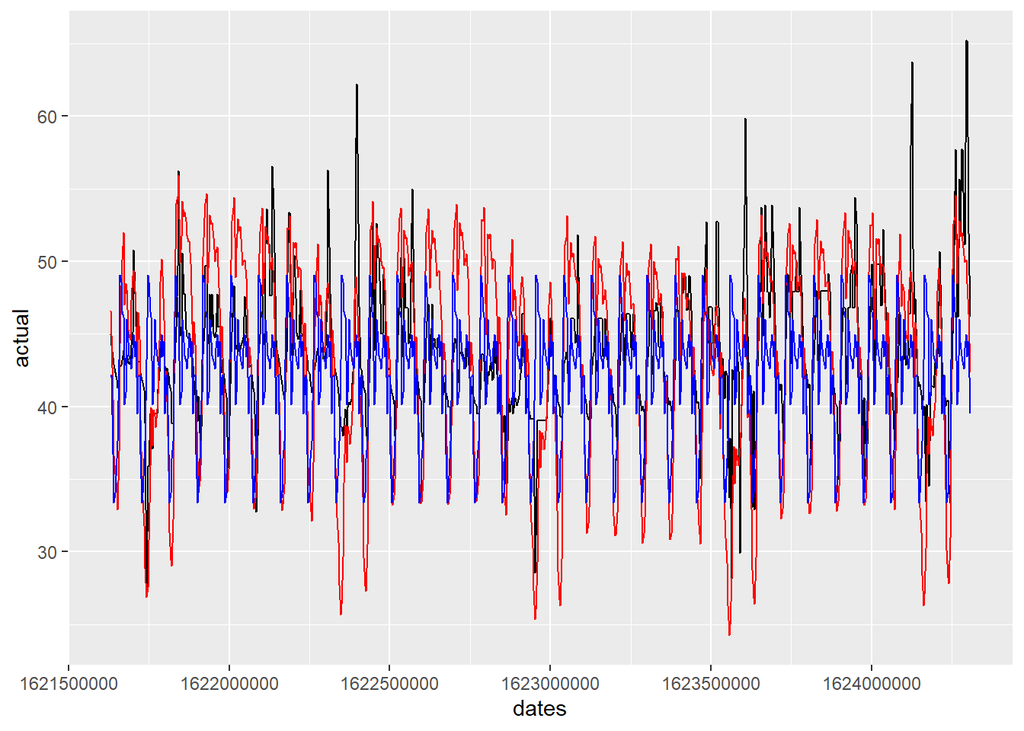

```r
dates <- tail(full_data$date_hour,24*length(test_dates))
data <-  as.data.frame( cbind(dates,actual,forecast1,forecast2))
ggplot(data, aes(x=dates)) +
  geom_line(aes(y=actual)) +
  geom_line(aes(y=forecast1),color="red") +
  geom_line(aes(y=forecast2),color="blue")
```

# 4 Conclusion

I decided on the regression model. Here are my forecasts for the test period; there are dates in the columns and hours in the rows.

```r
df2
```

```
##    2021-05-22 2021-05-23 2021-05-24 2021-05-25 2021-05-26 2021-05-27 2021-05-28
## 0    42.01962   42.01962   42.01962   42.01962   42.01962   42.01962   42.01962
## 1    42.19906   42.19906   42.19906   42.19906   42.19906   42.19906   42.19906
## 2    36.70265   36.70265   36.70265   36.70265   36.70265   36.70265   36.70265
## 3    33.39380   33.39380   33.39380   33.39380   33.39380   33.39380   33.39380
## 4    34.04278   34.04278   34.04278   34.04278   34.04278   34.04278   34.04278
## 5    36.40290   36.40290   36.40290   36.40290   36.40290   36.40290   36.40290
## 6    37.62433   37.62433   37.62433   37.62433   37.62433   37.62433   37.62433
## 7    43.21397   43.21397   43.21397   43.21397   43.21397   43.21397   43.21397
## 8    49.03924   49.03924   49.03924   49.03924   49.03924   49.03924   49.03924
## 9    48.56412   48.56412   48.56412   48.56412   48.56412   48.56412   48.56412
## 10   46.56071   46.56071   46.56071   46.56071   46.56071   46.56071   46.56071
## 11   46.17745   46.17745   46.17745   46.17745   46.17745   46.17745   46.17745
## 12   40.12655   40.12655   40.12655   40.12655   40.12655   40.12655   40.12655
## 13   40.99790   40.99790   40.99790   40.99790   40.99790   40.99790   40.99790
```

[output cut: 110 more lines]